# CensusMapper import playground

We demonstrate how to import data from the [CensusMapper](https://CensusMapper.ca) API. The code for this notbook can be found on [GitHub](https://github.com/mountainMath/r-censusmapper).

To work with the CensusMapper API we need to specify our API key. We load the API key in the environment variable “CM_API_KEY”, which we assume was set prior to running the script. We could also specify it directly in the code, but than we have to be careful not to expose our API key when sharing our code.

```r
# set environment variable via
# Sys.setenv(CM_API_KEY='<your API key>')
api_key=Sys.getenv('CM_API_KEY')
```

To tie into the CensusMapper API we utilize the “census_mapper” convenience function to load census data from CensusMapper.

```r
vectors=c("v_CA16_408","v_CA16_409","v_CA16_410","v_CA16_412","v_CA16_413","v_CA16_414","v_CA16_415","v_CA16_416","v_CA16_417")
regions_string='{"CMA":["59933"]}'

geos <- census_mapper(dataset='CA16',level='CT',regions=regions_string,vectors=vectors,api_key=api_key,geo=TRUE, force_download = FALSE)
```

Compute some values for mapping

```r
geos$sd <- geos$v_CA16_409..Single.detached.house / geos$v_CA16_408..Occupied.private.dwellings.by.structural.type.of.dwelling.data
#geos$sd[geos$v_CA16_409..Single.detached.house=='x']<-NA
```

Now we can use that data for analysis or mapping.

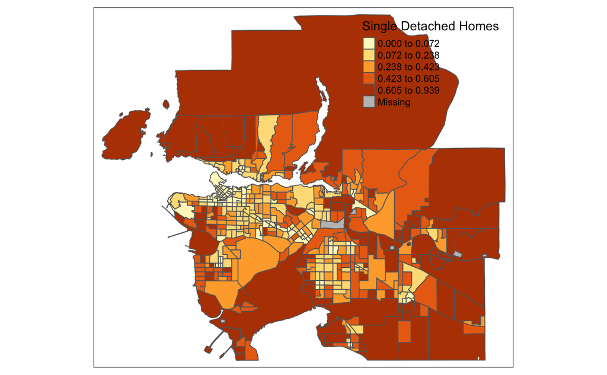

```r
library(tmap)
tm_shape(geos) +
  tm_polygons("sd", style="quantile", title="Single Detached Homes")
```

Or using the ggplot library.

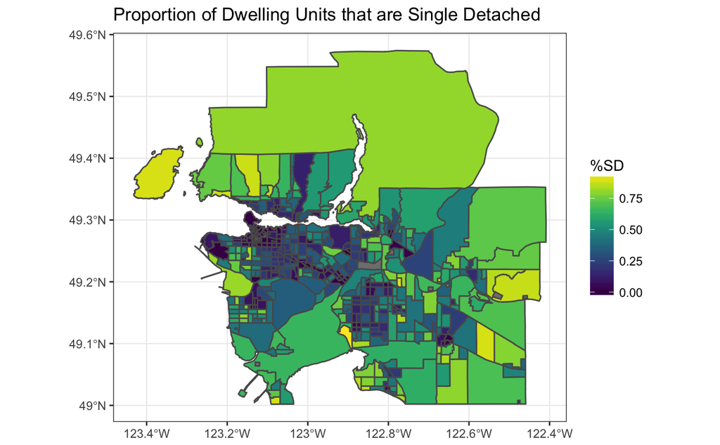

```r
# requires dev build of tiverse/ggplot2, install using devtools and install_github('tidyverse/ggplot2') if needed
library(sf)
library(tidyverse)
library(viridis)
library(rvest)
ggplot(geos) +
  geom_sf(aes(fill = sd)) +
  scale_fill_viridis("%SD") +
  ggtitle("Proportion of Dwelling Units that are Single Detached") +
  theme_bw()
```

Or we can explore the data through non-map based means, for example how the proportion of single detached and duplex dwelling relate. Duplex dwellings are in most cases suited single family homes. We can explore how the relationship between single family homes and duplexes depend on the municipal regulations allowing for secondary suites.

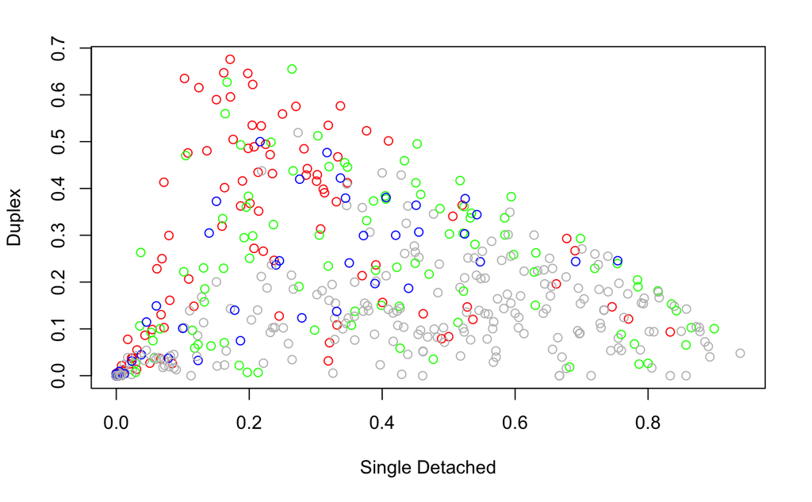

```r
geos$duplex <- geos$v_CA16_414..Apartment.or.flat.in.a.duplex/ geos$v_CA16_408..Occupied.private.dwellings.by.structural.type.of.dwelling.data
geos$color_code <- ifelse(geos$Region.Name == "Vancouver", 'red', ifelse(geos$Region.Name == "Burnaby", 'blue', ifelse(geos$Region.Name == "Surrey", 'green', 'grey')))
plot(geos$sd, geos$duplex, xlab="Single Detached", ylab="Duplex", col=geos$color_code)
```